# FA2 Data Mining and Wrangling

Bayquen, Christopher Gilbert A.

2024-02-25

## **CASE STUDY: MAJOR LEAGUE BASEBALL**

What is the relationship between payroll and wins among Major League Baseball (MLB) teams? In this homework, we’ll find out by wrangling, exploring, and modeling the dataset in MLPayData_Total.rdata, which contains the winning records and the payroll data of all 30 MLB teams from 1998 to 2014.

**1. WRANGLE**

**1.1. Importing the Necessary Packages and Data set into a Tibble**

```r
library(tidyverse) # tidyverse
library(ggrepel) # for scatter plot point labels
library(kableExtra) # for printing tables
library(cowplot)# for side by side plots
library(dplyr)
library(ggplot2)
library(ggrepel)
library(gggenes)

# loading in the data frame into a tibble
load("ml_pay.rdata")
mlb_raw <- as_tibble(ml_pay)
mlb_raw
```

| payroll | avgwin | Team.name.2014 | p1998 | p1999 | p2000 | p2001 | p2002 | p2003 | p2004 | p2005 | p2006 | p2007 | p2008 | p2009 | p2010 | p2011 | p2012 | p2013 | p2014 | X2014 | X2013 | X2012 | X2011 | X2010 | X2009 | X2008 | X2007 | X2006 | X2005 | … |
| --- | --- | --- | --- | --- | --- | --- | --- | --- | --- | --- | --- | --- | --- | --- | --- | --- | --- | --- | --- | --- | --- | --- | --- | --- | --- | --- | --- | --- | --- | --- |
| 1.1208736 | 0.4902585 | Arizona Diamondbacks | 31.61450 | 70.49600 | 81.02783 | 81.20651 | 102.82000 | 80.64033 | 70.20498 | 63.01583 | 59.68423 | 52.06755 | 66.20271 | 73.57167 | 60.71817 | 53.63983 | 74.28483 | 89.10050 | 112.68867 | 59 | 81 | 81 | 94 | 65 | 70 | 82 | 90 | 76 | 77 | … |
| 1.3817118 | 0.5527605 | Atlanta Braves | 61.70800 | 74.89000 | 84.53784 | 91.85169 | 93.47037 | 106.24367 | 88.50779 | 85.14858 | 90.15688 | 87.29083 | 102.36568 | 96.72617 | 84.42367 | 87.00319 | 83.30994 | 89.77819 | 110.89734 | 73 | 96 | 94 | 89 | 91 | 86 | 72 | 84 | 79 | 90 | … |
| 1.1612117 | 0.4538250 | Baltimore Orioles | 71.86092 | 72.19836 | 81.44743 | 72.42633 | 60.49349 | 73.87750 | 51.21265 | 74.57054 | 72.58558 | 93.55481 | 67.19625 | 67.10167 | 81.61250 | 85.30404 | 81.42900 | 90.99333 | 107.40662 | 82 | 85 | 93 | 69 | 66 | 64 | 68 | 69 | 70 | 74 | … |
| 1.9723587 | 0.5487172 | Boston Red Sox | 59.49700 | 71.72500 | 77.94033 | 109.55891 | 108.36606 | 99.94650 | 125.20854 | 121.31194 | 120.09982 | 143.02621 | 133.39004 | 122.69600 | 162.74733 | 161.40748 | 173.18662 | 150.65550 | 162.81741 | 62 | 97 | 69 | 90 | 89 | 95 | 95 | 96 | 86 | 95 | … |
| 1.4597668 | 0.4736557 | Chicago Cubs | 49.81600 | 42.14276 | 60.53933 | 64.01583 | 75.69083 | 79.86833 | 91.10167 | 87.21093 | 94.42450 | 99.67033 | 118.34583 | 135.05000 | 146.85900 | 125.48066 | 88.19703 | 104.30468 | 89.00786 | 64 | 66 | 61 | 71 | 75 | 83 | 97 | 85 | 66 | 79 | … |
| 1.3153909 | 0.5111170 | Chicago White Sox | 35.18000 | 24.53500 | 31.13350 | 62.36300 | 57.05283 | 51.01000 | 65.21250 | 75.22800 | 102.75067 | 108.67183 | 121.18933 | 96.06850 | 108.27320 | 129.28554 | 96.91950 | 119.07328 | 91.15925 | 63 | 63 | 85 | 79 | 88 | 79 | 89 | 72 | 90 | 99 | … |
| 1.0247816 | 0.4861602 | Cincinnati Reds | 20.70733 | 73.27846 | 46.86720 | 45.22788 | 45.05039 | 59.35567 | 43.06786 | 59.65828 | 60.90952 | 68.90498 | 74.11769 | 70.96850 | 72.38654 | 76.18136 | 82.20362 | 107.49130 | 112.39077 | 66 | 90 | 97 | 79 | 91 | 78 | 74 | 72 | 80 | 73 | … |
| 0.9991810 | 0.4959225 | Cleveland Indians | 59.54317 | 54.44250 | 75.88087 | 91.97498 | 78.90945 | 48.58483 | 34.56930 | 41.83040 | 56.03150 | 61.67327 | 78.97007 | 81.62557 | 61.20397 | 49.18887 | 78.43030 | 77.77280 | 82.53480 | 72 | 92 | 68 | 80 | 69 | 65 | 81 | 96 | 78 | 93 | … |
| 1.0261536 | 0.4633760 | Colorado Rockies | 47.71465 | 55.44350 | 61.11119 | 71.06800 | 56.85104 | 67.17967 | 64.59040 | 47.78900 | 41.23300 | 54.42400 | 68.65550 | 75.20100 | 84.22700 | 87.99807 | 78.06957 | 71.92407 | 95.83207 | 57 | 74 | 64 | 73 | 83 | 92 | 74 | 90 | 76 | 67 | … |
| 1.4297408 | 0.4822029 | Detroit Tigers | 19.23750 | 34.95967 | 58.26517 | 49.83117 | 55.04800 | 49.16800 | 46.35355 | 68.99818 | 82.61287 | 95.18037 | 137.68520 | 115.08514 | 122.86493 | 105.70523 | 132.30000 | 148.41450 | 162.22853 | 77 | 93 | 88 | 95 | 81 | 86 | 74 | 88 | 95 | 71 | … |

[output cut: 20 more lines]

> there are **30 rows** and **54 columns** in the *mlb_raw* tibble which matches perfectly with the data description provided.

**1.2. TIDY**

**AGGREGATED TIBBLE**

```r
# Tidy mlb_aggregate
mlb_aggregate <- mlb_raw %>%
  select(Team.name.2014, payroll, avgwin) %>%
  rename(team = Team.name.2014, payroll_aggregate = payroll, pct_wins_aggregate = avgwin)

mlb_aggregate
```

| team | payroll_aggregate | pct_wins_aggregate |
| --- | --- | --- |
| Arizona Diamondbacks | 1.1208736 | 0.4902585 |
| Atlanta Braves | 1.3817118 | 0.5527605 |
| Baltimore Orioles | 1.1612117 | 0.4538250 |
| Boston Red Sox | 1.9723587 | 0.5487172 |
| Chicago Cubs | 1.4597668 | 0.4736557 |
| Chicago White Sox | 1.3153909 | 0.5111170 |
| Cincinnati Reds | 1.0247816 | 0.4861602 |
| Cleveland Indians | 0.9991810 | 0.4959225 |
| Colorado Rockies | 1.0261536 | 0.4633760 |
| Detroit Tigers | 1.4297408 | 0.4822029 |

[output cut: 20 more lines]

**YEARLY TIBBLE**

```r
# Tidy mlb_yearly
mlb_yearly <- mlb_raw %>%
  select(team = Team.name.2014, starts_with("X"), starts_with("p")) %>%
  pivot_longer(-team, names_to = "year_values", values_to = "value")%>%

  mutate(
    metric = if_else(str_detect(year_values, "^p"), "payroll",
                     if_else(str_detect(year_values, "\\.pct$"), "pct_wins",
                             if_else(str_detect(year_values, "^X"), "num_wins", NA_character_))),
    year = str_extract(year_values, "\\d{4}")
  ) %>%

  filter(!is.na(metric)) %>%
    filter(!is.na(year)) %>%
    mutate(year = as.numeric(year), value = as.numeric(value)) %>%
    drop_na(value) %>%
    group_by(team, year, metric) %>%
    summarise(value = mean(value), .groups = 'drop') %>%
    pivot_wider(names_from = metric, values_from = value) %>%
      select(team, year, payroll, pct_wins, num_wins)


mlb_yearly
```

| team | year | payroll | pct_wins | num_wins |
| --- | --- | --- | --- | --- |
| Arizona Diamondbacks | 1998 | 31.61450 | 0.3987730 | 65 |
| Arizona Diamondbacks | 1999 | 70.49600 | 0.6134969 | 100 |
| Arizona Diamondbacks | 2000 | 81.02783 | 0.5246914 | 85 |
| Arizona Diamondbacks | 2001 | 81.20651 | 0.5679012 | 92 |
| Arizona Diamondbacks | 2002 | 102.82000 | 0.6049383 | 98 |
| Arizona Diamondbacks | 2003 | 80.64033 | 0.5185185 | 84 |
| Arizona Diamondbacks | 2004 | 70.20498 | 0.3148148 | 51 |
| Arizona Diamondbacks | 2005 | 63.01583 | 0.4753086 | 77 |
| Arizona Diamondbacks | 2006 | 59.68423 | 0.4691358 | 76 |
| Arizona Diamondbacks | 2007 | 52.06755 | 0.5521472 | 90 |

[output cut: 500 more lines]

**1.3. QUALITY CONTROL**

*checking the aggregated values*

```r
mlb_aggregate_computed <- mlb_yearly %>%
  group_by(team) %>%
  summarise(
    payroll_aggregate_computed = sum(payroll, na.rm = TRUE),
    pct_wins_aggregate_computed = mean(pct_wins, na.rm = TRUE)
  ) %>%
  ungroup()

mlb_aggregate_joined <- inner_join(mlb_aggregate, mlb_aggregate_computed, by="team")
mlb_aggregate_joined
```

| team | payroll_aggregate | pct_wins_aggregate | payroll_aggregate_computed | pct_wins_aggregate_computed |
| --- | --- | --- | --- | --- |
| Arizona Diamondbacks | 1.1208736 | 0.4902585 | 1222.9841 | 0.4921264 |
| Atlanta Braves | 1.3817118 | 0.5527605 | 1518.3098 | 0.5631539 |
| Baltimore Orioles | 1.1612117 | 0.4538250 | 1305.2710 | 0.4570920 |
| Boston Red Sox | 1.9723587 | 0.5487172 | 2103.5807 | 0.5512860 |
| Chicago Cubs | 1.4597668 | 0.4736557 | 1551.7256 | 0.4745898 |
| Chicago White Sox | 1.3153909 | 0.5111170 | 1375.1059 | 0.5069221 |
| Cincinnati Reds | 1.0247816 | 0.4861602 | 1118.7674 | 0.4913973 |
| Cleveland Indians | 0.9991810 | 0.4959225 | 1113.1666 | 0.5047025 |
| Colorado Rockies | 1.0261536 | 0.4633760 | 1129.3117 | 0.4626324 |
| Detroit Tigers | 1.4297408 | 0.4822029 | 1483.9380 | 0.4738311 |

[output cut: 20 more lines]

*plotting a scatter plot for each tibble*

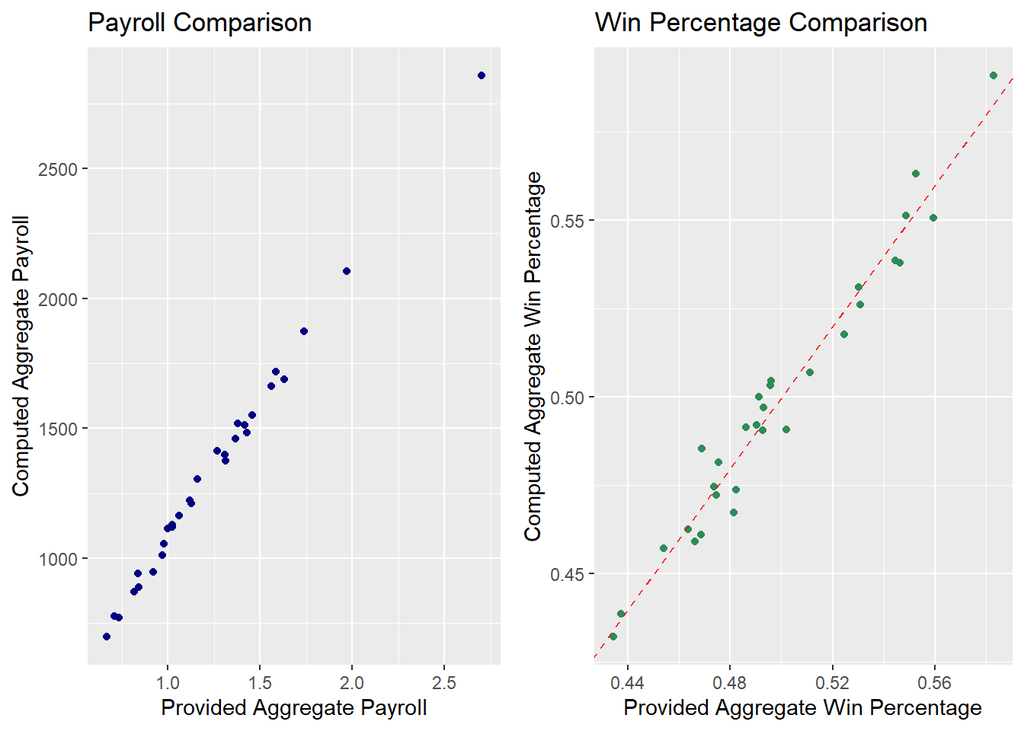

```r
# Scatter plot for payroll
payroll_plot <- ggplot(mlb_aggregate_joined, aes(x = payroll_aggregate, y = payroll_aggregate_computed)) +
  geom_point(color = "navyblue") +
  geom_abline(intercept = 0, slope = 1, linetype = "dashed", color = "red") +  # Add the 45-degree dashed red line
  labs(title = "Payroll Comparison",
       x = "Provided Aggregate Payroll",
       y = "Computed Aggregate Payroll")


# Scatter plot for win percentage
pct_wins_plot <- ggplot(mlb_aggregate_joined, aes(x = pct_wins_aggregate, y = pct_wins_aggregate_computed)) +
  geom_point(color="seagreen") +
  geom_abline(intercept = 0, slope = 1, color = "red", linetype = "dashed") +
  labs(title = "Win Percentage Comparison",
       x = "Provided Aggregate Win Percentage",
       y = "Computed Aggregate Win Percentage")

# Combine the plots side by side
combined_plots <- cowplot::plot_grid(payroll_plot, pct_wins_plot)
print(combined_plots)
```

> **interpretation:** As we can see in the *mlb_aggregate_joined* tibble, the values that we have manually computed and the given values in the data set are not exactly the same. The scatter plots above shows us a positively correlated relationship between the computed values and the provided aggregate statistics; one of the explanations to these would probably be that the given raw data of the aggregated payroll of each team for the duration of 17 years is in billions of dollars, while the raw data provided for the payroll of each year is in millions of dollars.

**2. EXPLORE**

**2.1 PAYROLL ACROSS YEARS**

**payroll as a function of year for each of the 30 teams**

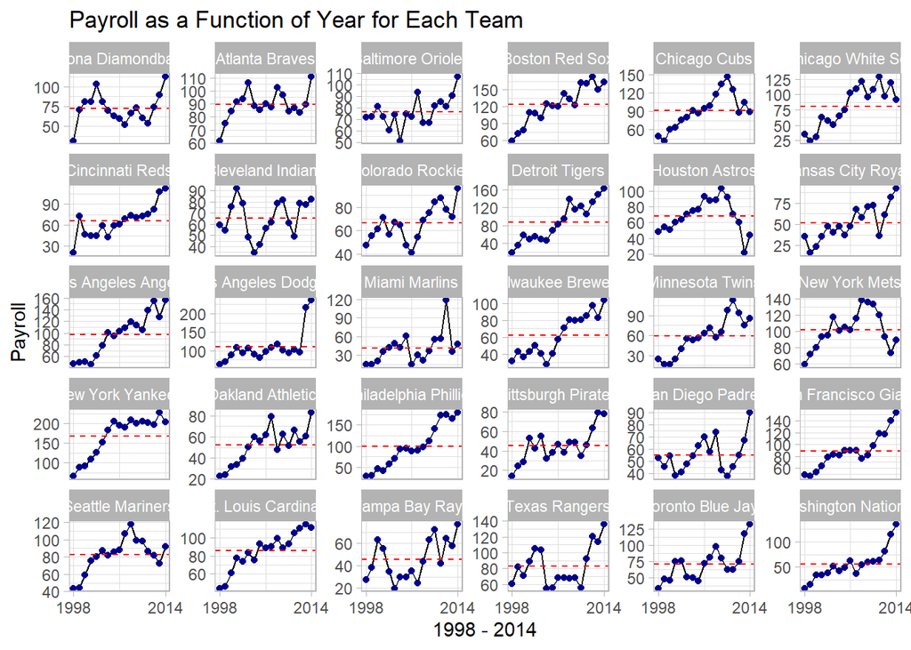

```r
ggplot(mlb_yearly, aes(x = as.numeric(year), y = payroll, group = team)) +
  geom_line() +
  geom_point(color="darkblue") +
  geom_hline(data = mlb_yearly %>% group_by(team) %>%
               summarise(mean_payroll = mean(payroll, na.rm = TRUE), .groups = 'keep'),
             aes(yintercept = mean_payroll), linetype = "dashed", color = "red") +
  facet_wrap(~team, scales = "free_y") +
  theme_light() +
  labs(title = "Payroll as a Function of Year for Each Team", x = "1998 - 2014", y = "Payroll") +
  scale_x_continuous(breaks = range(as.numeric(mlb_yearly$year)),  # Ensure range is numeric
                     labels = c(min(mlb_yearly$year), max(mlb_yearly$year))) +
  theme(axis.text.x = element_text(angle = 0))  # Set x-axis text angle
```

**three teams with the greatest payroll_aggregate_computed**

```r
top3_payroll <- mlb_aggregate_computed %>%
                arrange(desc(payroll_aggregate_computed)) %>%
                slice_head(n = 3)

top3_payroll
```

| team | payroll_aggregate_computed | pct_wins_aggregate_computed |
| --- | --- | --- |
| New York Yankees | 2857.093 | 0.5909819 |
| Boston Red Sox | 2103.581 | 0.5512860 |
| Los Angeles Dodgers | 1874.194 | 0.5261364 |

```r
result <- mlb_yearly %>%
  filter(year %in% c(1998, 2014)) %>%
  group_by(team) %>%
  summarise(payroll_1998 = payroll[year == 1998],
            payroll_2014 = payroll[year == 2014]) %>%
  ungroup() %>%
  mutate(pct_increase = ((payroll_2014 - payroll_1998) / payroll_1998) * 100) %>%
  head(3)

result
```

| team | payroll_1998 | payroll_2014 | pct_increase |
| --- | --- | --- | --- |
| Arizona Diamondbacks | 31.61450 | 112.6887 | 256.44614 |
| Atlanta Braves | 61.70800 | 110.8973 | 79.71307 |
| Baltimore Orioles | 71.86092 | 107.4066 | 49.46458 |

**2.2 WIN PERCENTAGE ACROSS YEARS**

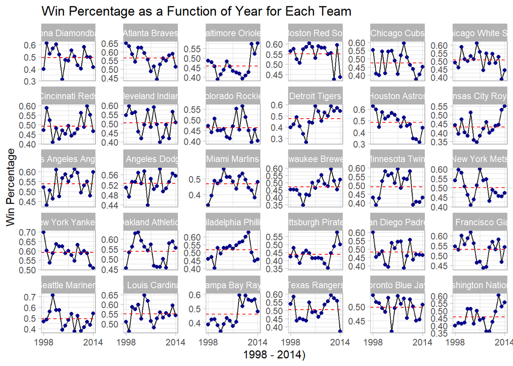

```r
mlb_yearly$year <- as.numeric(as.character(mlb_yearly$year))

ggplot(mlb_yearly, aes(x = year, y = pct_wins, group = team)) +
  geom_line() +
  geom_point(color="darkblue") +
  geom_hline(data = mlb_yearly %>% group_by(team) %>%
               summarise(mean_pct_wins = mean(pct_wins, na.rm = TRUE), .groups = 'keep'),
             aes(yintercept = mean_pct_wins), linetype = "dashed", color = "red") +
  facet_wrap(~team, scales = "free_y") +
  theme_light() +
  labs(title = "Win Percentage as a Function of Year for Each Team", x = "1998 - 2014)", y = "Win Percentage") +
  scale_x_continuous(breaks = range(mlb_yearly$year),
                     labels = c(min(mlb_yearly$year), max(mlb_yearly$year))) +
  theme(axis.text.x = element_text(angle = 0))
```

> **interpretation:** you would expect that throughout the years, the win percentage of the teams would probably have a positive slope considering that the more experience you get, the more skilled you should be getting. However, the trend of the plots above shows otherwise; some teams have a positive slope while some are zig-zagging throughout the years. This may be a result of inconsistent players, considering that the players in the teams probaby change from year to year.

**three teams with the greatest pct_wins_aggregate_computed**

```r
top3_agg<- mlb_aggregate_computed %>%
  arrange(desc(pct_wins_aggregate_computed)) %>%
  slice_head(n = 3)

top3_agg
```

| team | payroll_aggregate_computed | pct_wins_aggregate_computed |
| --- | --- | --- |
| New York Yankees | 2857.093 | 0.5909819 |
| Atlanta Braves | 1518.310 | 0.5631539 |
| Boston Red Sox | 2103.581 | 0.5512860 |

**the Three Teams with the Most Erratic pct_wins**

```r
top3_err <- mlb_yearly %>%
  group_by(team) %>%
  summarise(pct_wins_sd = sd(pct_wins, na.rm = TRUE)) %>%
  arrange(desc(pct_wins_sd)) %>%
  slice_head(n = 3)

top3_err
```

| team | pct_wins_sd |
| --- | --- |
| Houston Astros | 0.09143357 |
| Detroit Tigers | 0.08976544 |
| Seattle Mariners | 0.08922714 |

## **2.3 SCATTER PLOTS**

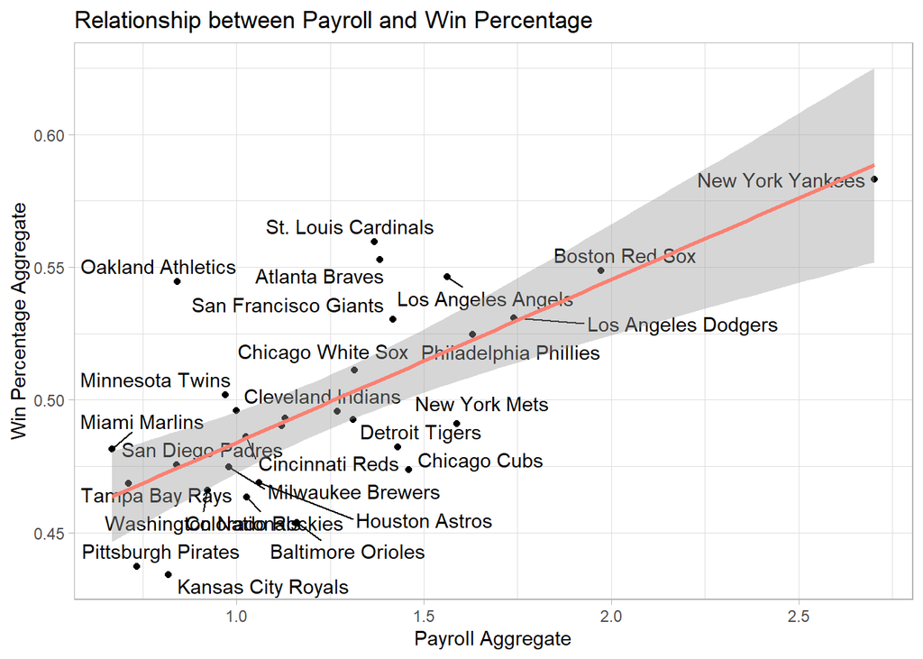

```r
library(ggrepel)
ggplot(mlb_aggregate, aes(x = payroll_aggregate, y = pct_wins_aggregate, label = team)) +
  geom_point() +
  geom_text_repel() +
  geom_smooth(method = "lm", color = "salmon") +
  theme_light() +
  labs(title = "Relationship between Payroll and Win Percentage",
       x = "Payroll Aggregate",
       y = "Win Percentage Aggregate")
```

> **interpretation:** In Major League Baseball, there exists a positive correlation between payroll and win percentage, as depicted in the scatter plot. This conforms to the anticipated notion that higher financial investment can contribute positively to a team’s overall performance. Nevertheless, the correlation is not flawless, and there are instances where teams either surpass or fall short of expectations relative to their payroll. This phenomenon suggests the presence of other variables influencing team performance beyond financial expenditure.